# Aufgaben

## Aufgaben

#### Aufgabe

1. Welchen z-Wert hat eine Beobachtung mit
   $$x=35$$
   bei einer Normalverteilung mit $\mu=50$ und $\sigma=5$?
   1. 0
   2. -2
   3. -3
   4. 3

#### Aufgabe

2. Geben Sie den (am besten passenden) Wert der Verteilungsfunktion $F$ für das im Folgenden dargestellten Quantil $q$ an.

   Gehen Sie von dieser Verteilung aus: $\mathcal{N}(\mu = 0, \sigma = 1)$.

   Das Quantil lautet: -2.
   1. 0.16
   2. 0.84
   3. 0.02
   4. 0.50
   5. 0.98

#### Aufgabe

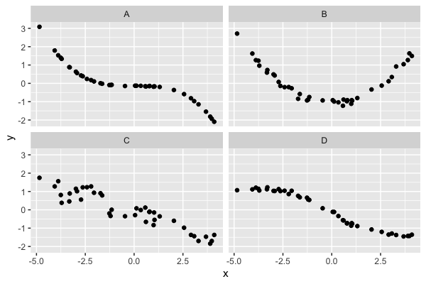

3. Bei welcher der Abbildungen ist einer Regression mit linearem Graph angemessen?
   1. A
   2. B
   3. C
   4. D

#### Aufgabe

4. Die beiden folgenden Abbildungen zeigen zwei lineare Regressionen.

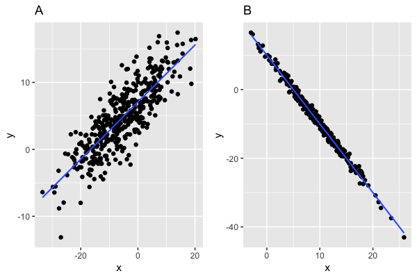

   Welche Aussage stimmt?
   1. $R^2_A < R^2_B$
   2. $R^2_A \approx R^2_B$
   3. $R^2_A > R^2_B$

#### Aufgabe

5. Prof. Salzig untersucht eine seiner Lieblingsfragen: Wie viel bringt das Lernen auf eine Klausur? Dabei konzentriert er sich auf das Fach Statistik (es gefällt ihm gut). In einer aktuellen Untersuchung hat er $n=60$ Studierende untersucht (s. Tabelle und Diagramm) und jeweils erfasst, ob die Person die Klausur bestanden (b) hat oder durchgefallen (d) ist. Dabei hat er zwei Gruppen unterschieden: Die “Viel-Lerner” (VL) und die “Wenig-Lerner” (WL).

   Berechnen Sie die folgende *bedingte Wahrscheinlichkeit*: p(Bestehen|Viellerner).

   *Beispiel*: Wenn Sie ausrechnen, dass die Wahrscheinlichkeit bei 42 Prozentpunkten liegt, so geben Sie ein: `0,42` bzw. `0.42` (das Dezimalzeichen ist abhängig von Ihren Spracheinstellungen).

   *Hinweise*:
   - Geben Sie *nur eine Zahl* ein (ohne Prozentzeichen o.Ä.), z.B. `0,42`.
   - Andere Angaben können u.U. nicht gewertet werden.
   - Runden Sie auf zwei Dezimalstellen.
   - Achten Sie darauf, das *korrekte Dezimaltrennzeichen* einzugeben; auf Geräten mit deutscher Spracheinstellung ist dies oft ein Komma.

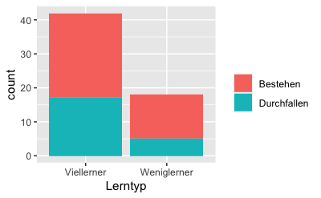

   Ergebnisse der Studie

   |  | Viellerner | Weniglerner |
   | --- | --- | --- |
   | Bestehen | 25 | 13 |
   | Durchfallen | 17 | 5 |

#### Aufgabe

6. Als Bildungsforscher(in) untersuchen Sie den Lernerfolg in einem Statistikkurs.

   Eine Gruppe von Studierenden absolviert einen Statistikkurs. Ein Teil lernt gut mit (Ereignis $A$), ein Teil nicht (Ereignis $A^C$). Ein Teil besteht die Prüfung (Ereignis $B$); ein Teil nicht ($B^C$).

   Hinweis: Das Gegenereignis zum Ereignis $A$ wird oft das Komplementärereignis oder kurz Komplement von $A$ genannt und mit $A^C$ bezeichnet.

   Wir ziehen zufällig eine/n Studierende/n: Siehe da – Die Person hat bestanden. Yeah!

   **Aufgabe**: Gesucht ist die Wahrscheinlichkeit, dass *diese Person* gut mitgelernt hat, gegeben der Tatsache, dass dieser Person bestanden hat.

   Die Anteile der Gruppen (bzw. Wahrscheinlichkeit des Ereignisses) lassen sich unten stehender Tabelle entnehmen.

   | row_ids | B | Bneg |
   | --- | --- | --- |
   | A | 0.59 | 0.10 |
   | Aneg | 0.23 | 0.07 |

   *Hinweise*:
   - Runden Sie auf 2 Dezimalstellen.
   - Geben Sie Anteile stets in der Form `0.42` an (mit führender Null und Dezimalzeichen).
   - “Aneg” bezieht sich auf das Komplementärereignis zu A.
   1. Zeichnen Sie (per Hand) ein Baumdiagramm, um die gemeinsamen Wahrscheinlichkeiten darzustellen. Weiterhin sollen die Randwahrscheinlichkeiten für $A$ dargestellt sein.
   2. Zeichnen Sie (per Hand) ein Baumdiagramm, um diesen Sachverhalt darzustellen.
   3. Geben Sie die Wahrscheinlichkeit des gesuchten Ereignisses an.

#### Aufgabe

7. Als Bildungsforscher(in) untersuchen Sie den Lernerfolg in einem Statistikkurs.

   Eine Gruppe von Studierenden absolviert einen Statistikkurs. Ein Teil lernt gut mit (Ereignis $A$), ein Teil nicht (Ereignis $A^C$). Ein Teil besteht die Prüfung (Ereignis $B$); ein Teil nicht ($B^C$).

   Wir ziehen zufällig eine/n Studierende/n: Siehe da – Die Person hat bestanden. Yeah!

   Die Anteile der Gruppen (bzw. Wahrscheinlichkeit des Ereignisses) lassen sich unten stehender Tabelle entnehmen.

   | row_ids | B | Bneg | Summe |
   | --- | --- | --- | --- |
   | A | 0.78 | 0.13 | 0.91 |
   | A_neg | 0.07 | 0.02 | 0.09 |
   | Summe | 0.86 | 0.15 | 1.01 |

   **Aufgabe**: Gesucht ist die (bedingte) Wahrscheinlichkeit, dass *diese Person* gut mitgelernt hat, gegeben der Tatsache, dass sie bestanden hat. Geben Sie die Wahrscheinlichkeit des gesuchten Ereignisses an!

   *Hinweise*:
   - Runden Sie auf 2 Dezimalstellen.
   - Geben Sie Anteile stets in der Form `0.42` an (mit führender Null und Dezimalpunkt).
   - “A_neg” bezieht sich auf das Komplementärereignis zu A.

#### Aufgabe

8. Betrachten wir das Ereignis “Schwerer Coronaverlauf” ($S$); ferner betrachten wir das Ereignis “Blutgruppe ist A” ($A$) und das Gegenereignis von $A$: “Blutgruppe ist nicht A”. Ein Gegenereignis wird auch als *Komplementärereignis* oder auch als *Komplement* (complement) mit dem Term $A^C$ bezeichnet.

   Sei $Pr(S|A) = 0.01$ und sei $Pr(S|A^C) = 0.01$.

   Was kann man auf dieser Basis zur Abhängigkeit der Ereignisse $S$ und $A$ sagen?

#### Aufgabe

9. Ein renommiertes Unternehmen sucht einen Kandidaten für eine (hoch dotierte) Führungsposition. Ein Managementberatungsunternehmung führt ein Assessmentcenter durch, welches pro Kandidat/in eine positive bzw. negative Empfehlung ergibt. Aus früheren Erfahrungen heraus wissen die Berater, dass die tatsächlich geeigneten Kandidaten (Ereignis $E$ wie *eligible*) mit $60\%$ eine positive Empfehlung für die Stelle ausgesprochen bekommen (Ereignis $R$ wie *recommendation*). Weiterhin bekommen von den *nicht* geeigneten Kandidaten $64\%$ eine negative Empfehlung. Insgesamt wissen die Berater, dass $7\%$ der Bewerber/innen tatsächlich geeignet sind.

   Was ist die entsprechende Häufigkeitstabelle? Geben Sie alle vier Einträge in Prozent an!

   *Hinweis*: Das Gegenereignis vom Ereignis $A$ wird als Komplementärereignis oder kurz als Komplement bezeichnet und mit $A^C$ oder $\overline{A}$ abgekürzt. Im vorliegenden Fall meint $\overline{R}=R^C$ das Ereignis, dass ein Kandidat *keine* Empfehlung ausgesprochen bekommt.
   1. $P(E \cap R)$
   2. $P(\overline{E} \cap R)$
   3. $P(E \cap \overline{R})$
   4. $P(\overline{E} \cap \overline{R})$

#### Aufgabe

10. Wir betrachten einen Datensatz, der Kredite analysiert:

    ```
    library(openintro)
    data("loans_full_schema")
    ```

    [Quelle](http://openintrostat.github.io/openintro/reference/loans_full_schema.html)

    Eine Analystin möchte den Zinssatz (`interest_rate`) auf Basis dieses Datensatzes vorhersagen.

    Sie berechnet folgendes Regressionsmodell:

    ```
    lm1 <- lm(interest_rate ~ annual_income + application_type, data = loans_full_schema)
    ```

    Folgende Ergebnisse bekommt Sie zurück geliefert:

    | term | estimate | std_error |
    | --- | --- | --- |
    | intercept | 12.90 | 0.08 |
    | annual_income | 0.00 | 0.00 |
    | application_typejoint | 0.71 | 0.14 |

    Welche Aussage ist korrekt?
    1. `Estimate` liefert eine Schätzung zur Modellgüte.
    2. Das Verhältnis von Signal zu Rauschen für `application_typejoint` ist kleiner als 1.
    3. Es liegt ein Fehler vor, denn `application_typejoint` hat neben `joint` noch eine weitere Stufe (`individual`), diese ist aber nicht aufgeführt.
    4. Der Wert bei `Intercept` gibt den Wert der abhängigen Variable an, bei Fällen mit dem Wert `individual` bei `application_type` und ohne Jahreseinkommen.
    5. Der Wert bei `Intercept` gibt den Wert der abhängigen Variable an, bei Fällen mit dem Wert `joint` bei `application_type` und ohne Jahreseinkommen.

#### Aufgabe

11. Betrachten Sie folgendes Modell, das den Zusammenhang des Preise (`price`) und dem Gewicht (`carat`) von Diamanten untersucht (Datensatz `diamonds`).

    ```
    library(tidyverse)
    data(diamonds)
    ```

    Aber zuerst zentrieren wir den metrischen Prädiktor `carat`, um den Achsenabschnitt besser interpretieren zu können.

    ```
    diamonds <-
      diamonds %>%
      mutate(carat_z = carat - mean(carat, na.rm = TRUE))
    ```

    ```
    library(rstanarm)
    lm1 <- stan_glm(price ~ carat_z, data = diamonds,
                    refresh = 0)
    summary(lm1)
    ```

    ```
    Estimates:
                  mean   sd     10%    50%    90%
    (Intercept) 3932.5    6.8 3923.7 3932.5 3941.1
    carat_z     7756.3   14.2 7737.8 7756.2 7774.7
    sigma       1548.6    4.8 1542.5 1548.6 1554.7
    ```

    Zur Verdeutlichung ein Diagramm zum Modell:

    ```
    diamonds %>%
      ggplot() +
      aes(x = carat_z, y = price) +
      geom_point() +
      geom_smooth(method = "lm")
    ```

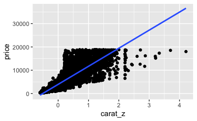

    1. Was kostet in Diamant mittlerer Größe laut Modell `lm1`?
    2. Geben Sie eine Regressionsformel an, die `lm1` ergänzt, so dass die Schliffart (`cut`) des Diamanten kontrolliert (adjustiert) wird. Anders gesagt: Das Modell soll die mittleren Preise für jede der fünf Schliffarten angeben.

    *Hinweis*: Es gibt (laut Datensatz) folgende Schliffarten (und zwar in der folgenden Reihenfolge):

    ```
    diamonds %>%
      distinct(cut)
    ```

    | cut |
    | --- |
    | Ideal |
    | Premium |
    | Good |
    | Very Good |
    | Fair |

    ```
    levels(diamonds$cut)
    ```

    ```
    ## [1] "Fair"      "Good"      "Very Good" "Premium"   "Ideal"
    ```

#### Aufgabe

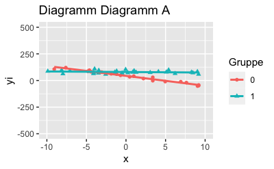

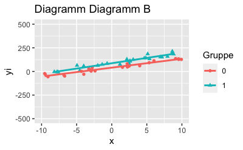

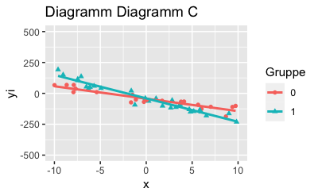

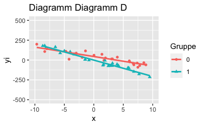

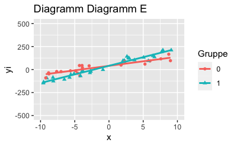

12. Wählen Sie das Diagramm, in dem *kein* Interaktionseffekt (in der Population) vorhanden ist (bzw. wählen Sie Diagramm, dass dies am ehesten darstellt).
    1. Diagramm A
    2. Diagramm B
    3. Diagramm C
    4. Diagramm D
    5. Diagramm E

#### Aufgabe

13. Der *t-Test* kann als Spezialfall der Regressionsanalyse gedeutet werden.

    Hierbei ist es wichtig, sich das Skalenniveau der Variablen, die ein t-Test verarbeitet, vor Augen zu führen.
    1. Benennen Sie die Skalenniveaus (UV, AV) eines t-Tests!
    2. Nennen Sie eine beispielhafte Forschungsfrage für einen t-Test.
    3. Skizzieren Sie ein Diagramm einer Regression, die analytisch identisch (oder sehr ähnlich) zu einem t-Test ist!

#### Aufgabe

14. Betrachten Sie folgende Ausgabe eines Bayesmodell, das mit `rstanarm` “gefittet” wurde:

    ```
    ## stan_glm
    ##  family:       gaussian [identity]
    ##  formula:      price ~ cut
    ##  observations: 1000
    ##  predictors:   5
    ## ------
    ##              Median  MAD_SD
    ## (Intercept)   4571.7   675.1
    ## cutGood       -570.2   777.2
    ## cutIdeal     -1288.3   688.1
    ## cutPremium     362.5   709.8
    ## cutVery Good  -807.4   706.3
    ##
    ## Auxiliary parameter(s):
    ##       Median MAD_SD
    ## sigma 3795.0   82.4
    ```

    Welche Aussage passt (am besten)?

    Hinweise:
    - Mit “Nullhypothese” ist im Folgenden dieser Ausdruck gemeint: $\mu_1 = \mu_2 = \ldots = \mu_k$.
    1. Die Nullhypothese muss verworfen werden.
    2. Die Nullhypothese muss beibehalten werden.
    3. Unter der Annahmen, dass die Posteriori-Verteilung für jeden Regressionsparameter normal verteilt ist, kann man schließen, dass bei allen Gruppenmittelwerte 95% der Posteriori-Verteilung ungleich Null sind.
    4. Unter der Annahmen, dass die Posteriori-Verteilung für jeden Regressionsparameter normal verteilt ist, kann man schließen, dass *nicht* bei allen Gruppenmittelwerte 95% der Posteriori-Verteilung ungleich Null sind.
    5. Unter der Annahmen, dass die Posteriori-Verteilung für jeden Regressionsparameter normal verteilt ist, kann man schließen, dass bei allen Gruppenmittelwerte 95% der Posteriori-Verteilung ungleich Null sind. Daher muss die Nullhypothese verworfen werden.

#### Aufgabe

15. Berechnet man eine Posteriori-Verteilung mit `stan_glm()`, so kann man entweder die schwach informativen Prioriwerte der Standardeinstellung verwenden, oder selber Prioriwerte definieren.

    Betrachten Sie dazu dieses Modell:

    ```
    stan_glm(price ~ cut, data = diamonds,
                       prior = normal(location = c(100, 100, 100, 100),
                                      scale = c(100, 100, 100, 100)),
                       prior_intercept = normal(3000, 500))
    ```

    Wie viele Parameter gibt es in diesem Modell?

    Hinweise:
    - Geben Sie nur eine (ganze) Zahl ein.

#### Aufgabe

16. Sei $r_{xy}=0.7, s_x=1, s_y=1$.

    Berechnen Sie $b$, den empirischen Regressionskoeffizienten!

#### Aufgabe

17. Eine Bayes-Analyse setzt voraus, dass Priori-Verteilungen definiert sind. Man kann aber die Prioris so setzen, dass die Modellparameter numerisch identisch zur frequentistischen Analyse sind.
    1. Nennen Sie den Namen des Befehls (R-Funktion) einer Bayes-Regression aus dem R-Package `rstanarm`!
    2. Nennen Sie den Namen eines Befehls (R-Funktion) einer frequentistischen Regression!
    3. Auf welchen Wert muss man die die Argumente von A) setzen, um numerisch äquivalente Ergebnisse zu B) zu erhalten? Geben Sie das passende “R-Wort” dafür ein.
    4. Wie viele Parameter sind in einem Modell zu spezifizieren, dass den Spritverbrauch als lineare Funktion der PS-Zahl modelliert? Geben Sie die Zahl ein.

    Hinweise:
    - Geben Sie bei R-Funktionen nur den Namen ein, keine Namen oder Argumente.
    - Verwenden Sie nur Kleinbuchstaben (z.b. mean, heute, klein, befehl).
    - Zahlen sind mit Ziffern, nicht in Wörtern einzugeben (richtig: 42, falsch: zweiundvierzig).

#### Aufgabe

18. Welche Verteilung ist (am besten) geeignet, um Streuung ($\sigma$) zu modellieren?
    1. N(0,1)
    2. N(1,1)
    3. Exp(1)
    4. Exp(0)
    5. Exp(-1)

#### Aufgabe

19. Gegeben sei die Theorie (oder schlichter: das Modell), demzufolge eine Anlage zu Suchtverhalten die Ursache von sowohl Rauchen als auch Kaffeegewohnheit darstellt. Lungenkrebs wiederum hat als (alleinige) Ursache Rauchen (laut diesem Modell).

    Daten zeigen, dass Kaffeegenuss und Lungenkrebs assoziiert sind: Bei Kaffeetrinkern ist die Lungenkrebsrate höher als bei Nichttrinkern (von Kaffee). Ob Kaffeegebrauch Lungenkrebs erzeugt?

    Eine alternative Erklärung bietet folgender DAG.

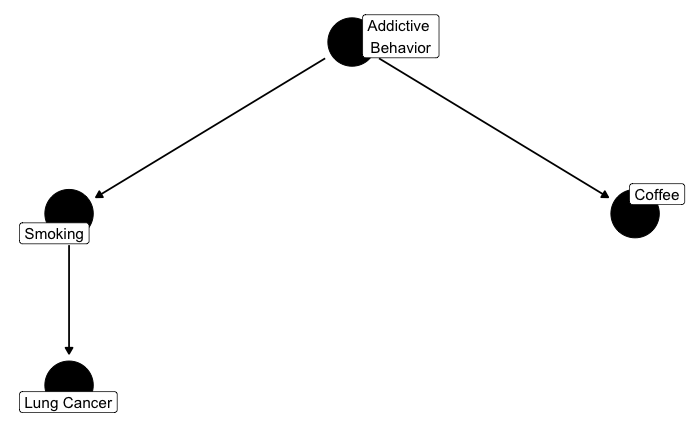

    Welche Variablenmenge muss *mindestens* kontrolliert werden, um Konfundierung auszuschließen und damit den kausalen Effekt von Kaffee auf Lungenkrebs zu identifizieren?
    1. {Addictive Behavior *und* Lungenkrebs}
    2. {Rauchen}
    3. {Addictive Behavior *und* Rauchen}
    4. {Addictive Behavior *oder aber* Rauchen}
    5. {Addictive Behavior}

#### Aufgabe

20. Ein Forschungsteam aus Epidemiologen untersucht den (möglicherweise kausalen) Zusammenhang von Erziehung (`education`) und Diabetes (`diabetes`). Das Team schlägt folgendes Modell zur Erklärung des Zusammenhangs vor (s. DAG).

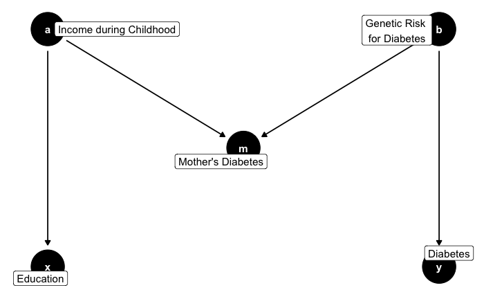

    Nochmal den gleich DAG ohne “Schilder”, damit man die Pfeilspitzen besser sieht:

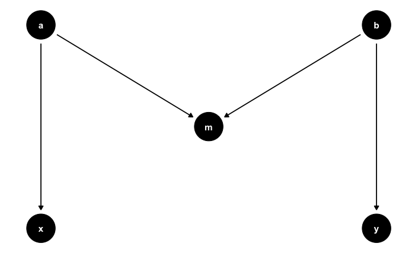

    Sollte die Krankengeschichte der Mutter hinsichtlich Diabetes kontrolliert werden, um den kausalen Effekt von Erziehung auf Diabetes zu identifizieren?
    1. Nein, `Mother's Diabetes` sollte *nicht* kontrolliert werden, da zwar keine Verzerrung entsteht, es aber auch nicht nötig ist.
    2. Ja, `Mother's Diabetes` sollte kontrolliert werden, da so ein Collider Bias (Kollisionsverzerrung) vermieden wird.
    3. Nein, `Mother's Diabetes` sollte *nicht* kontrolliert werden, da so eine Konfundierung resultiert.
    4. Nein, `Mother's Diabetes` sollte *nicht* kontrolliert werden, da so ein Collider Bias (Kollisionsverzerrung) resultiert.
    5. Ja, `Mother's Diabetes` sollte kontrolliert werden, da so eine Konfundierung vermieden wird.

#### Aufgabe

21. Ein Forschungsteam aus Psychologen und Medizinern untersucht die Frage, ob Menschen, die eine hohe Bereitschaft für eine OP und zu Veränderung in ihrer Lebensführung aufweisen (mittels Fragebogen gemessen), nach einem Jahr über einen höheren Schmerzrückgang verfügen als Patienten geringerer Bereitschaft. Die Studie umfasst ausschließlich Patienten, die eine OP wegen Rückenschmerzen durchlaufen sind (s. DAG).

    Das Studiendesign impliziert, dass nur Patienten, die eine OP durchlaufen haben, in die Studie aufgenommen wurde. Damit wird per Design diese Variable stratifiziert (kontrolliert).

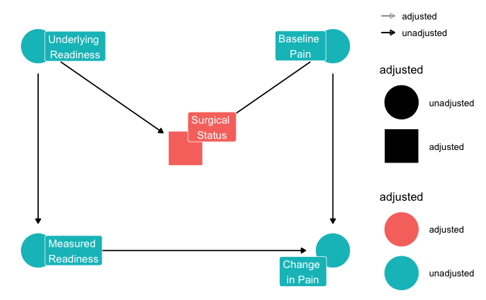

    Durch die Stratifizierung wird ein Hintertürpfad geöffnet; dieser muss geschlossen werden. Wie sollte dies geschehen (in diesem Modell)?

    Im folgenden Diagramm ist der Kollisionsbias kenntlich gemacht, der durch die Stratifizierung von `Surgical Status` entsteht:

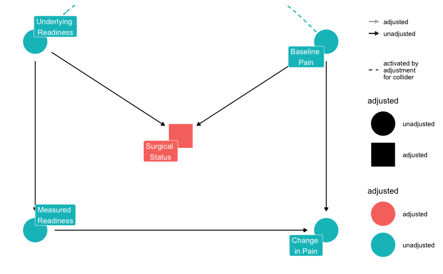